# 4. KOŞULLU VE MANTIKSAL İFADELER

## 4.1. Koşullu İfadeler

Program yazarken kodlar sıralı olarak alt alta satırlar şeklinde yazılır. Programın akışında bazı dallanmalar (farklı durumlar için farklı kodların çalışmasını istediğimiz durumlar) olabilir. Programlarda belirli koşul veya durumlar için çalışması istenen kodlar koşullu ifade blokları kullanılarak oluşturulur. Örneğin, sadece üyelerin giriş yapabileceği bir program hazırlarken kullanıcı adı ve parolası doğru olan kişilerin sisteme erişimine izin veren kodlar yazılır. Bunun için programa koşul ifadeleri eklenmesi gerekir. Koşul sağlanıyorsa menülere erişim izni verecek kodlar çalışmaya başlar. Koşul sağlanmıyorsa uyarı mesajı verilerek sisteme giriş izni verilmez.

Mantıksal operatörler sonuç olarak “boolean” veri tipinde değer verir. Eğer koşul sağlanırsa “True” değeri döndürürken koşul sağlanmazsa “False” değeri döndürür. “Boolean” veri tipi bu iki değerden başka bir değer alamaz. Bu durum koşullu ifadeler üretme olanağı sağlar. Koşullu ifadelerin sonucu “boolean” değer kontrol edilerek program akışı yönlendirilebilir. Koşul ifadesi ve “True-False” akışı Şekil 4.2’de daha iyi görülebilir.

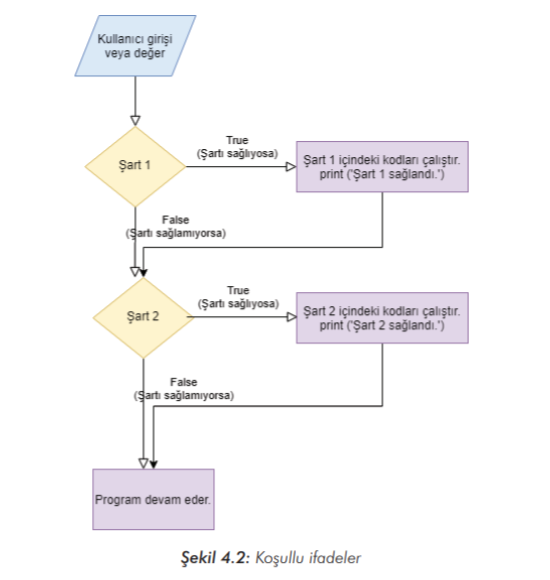

Şekil 4.2’de görüldüğü üzere kullanıcıdan alınan veri “Şart 1” yapısına geldiğinde şartı sağlıyorsa (True) bu kod girintisi (blok) içindeki komutlar çalışır. “Şart 1” yapısında şart sağlanmıyorsa “blok” atlanarak sonraki kodlara geçilir. Sonrasında yeni şart yapısı (Şart 2) aynı şekilde kontrol edilir ve akış devam eder

## 4.2. Mantıksal İfadeler ve Bağlaçlar

Bir mantıksal ifadeyi diğer mantıksal ifadelerle bağlamanın farklı yolları vardır. Modül 2’de açıklanan ilişkisel operatörler ve mantıksal bağlaçlar kullanılarak (or, and, not vb. gibi) farklı koşul durumları oluşturulabilir. kulaniciAdi==’Admin’ and kullaniciParola==’123456’ Kullanıcı adı ve parola doğru girilirse “True” değeri döndürür

**Örnek 1**

Aşağıdaki örnek kodda kullanıcı adı ve şifresi doğru girilirse ekrana “True” ikisinden biri bile yanlış olursa “False” değeri döndürür.

```python
kullaniciAdi=input('Kullanıcı Adı:')
kullaniciParola=input('Parola:')
print(kullaniciAdi=='Admin' and kullaniciParola=='123456')

>>> Kullanıcı Adı:Admin
>>> Parola:123456
>>> True
```

**Örnek 2** Bölümü Bilgisayar veya Elektronik olanları seçmek için bir kod yazalım. bolum==’Bilgisayar’ “or” bolum==’Elektronik’ koşullarından biri doğruysa “True” değilse “False” değeri döndürür.

```python
bolum=input('Bölümünüzü giriniz: ')
#Büyük harf küçük harf duyarlılığını ulatmayın
print(bolum=='Bilgisayar' or bolum=='Elektronik')

>>> Bölümünüzü giriniz: Bilgisayar
>>> True
```

Örneklerde sadece mantıksal operatörlerin sonucu “boolean” değeri ekrana yazdırıldı. Mantıksal operatörler koşul ifadeleriyle birlikte kullanıldığında belirli şartlarda belirli kod blokları çalıştırılabilir.

## 4.3. Python Blok Yapısı

Python’da (başka programlama dillerinde de) kodlar belirli alt kümeler hâlinde (blok) ifade edilir. Bu yapı Python’da girinti (Indentation) ile oluşturulur. Python’da dikey olarak aynı hizadaki kodlar aynı blok yapısında yer alır. Kod bloklarının kolaylıkla ayırt edilebilmesi için bir sekme (4 karakter boşluk) kullanılması önerilmektedir. Eğer bir IDE (bütünleşik program geliştirme ortamı) kullanılıyorsa bu girintiler otomatik olarak ayarlanacaktır. Kullanılan geliştirme ortamında ayarlar bölümünde bir girintinin kaç karakter olacağının belirlendiği ayarlar bulunmaktadır. Bir karakter boşluk ile oluşturulan girinti bile yeni blok yapısını oluşturur. Bir kod bloğu kendi içinde tutarlı bir yapıdır. Döngüler, fonksiyonlar ve koşul ifadeleri kod blokları kullanılarak oluşturulur

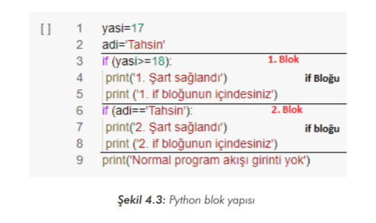

Şekil 4.3’te “if” ifadesinin altında girinti oluşturularak bir blok (1. Blok) oluşturulmuştur. “yasi>=18” mantıksal ifadesinin sonucu blok içindeki kodların tamamının atlanmasına veya çalıştırılmasına neden olur. Şekilde iki blok yapısı görünmektedir. Python’da kod yazarken girintilere dikkat etmek gerekir. Girintiler blok yapısını belirlediği için programın yanlış çalışmasına veya çalışmamasına neden olabilir.

**Örnek 3**

Aşağıda herhangi bir karar yapısı, döngü veya fonksiyon olmadan ikinci satırdaki kodu girintili yazıldığı için hata verir

```python
print('Blok yapısı')
 print('Girinti')

>>> File "<ipython-input-7-b54d1a37c7f1>", line 2
>>>  print('Girinti')
>>>  ^
>>> IndentationError: unexpected indent
```